# Part II - Key Insight On the Prosper Loan Analysis

## Dataset Overview

Our research on the Prosper loan dataset analyzed 113,937 loans, each with 81 variables, including loan amount, borrower rate, loan status, borrower income, and others. After a thorough evaluation, we cleaned and optimized the dataset for a more in-depth analysis.

## What is the distribution of borrower APR, borrower rate, lender yield, and estimated effective yield?

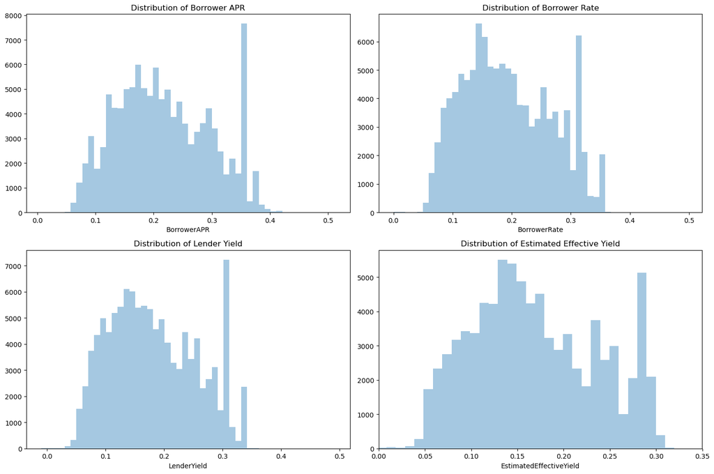

## How does homeownership impact loan performance?

Homeownership appeared to have an impact on loan performance, with the most common loan status for both homeowners and non-homeowners being "Active", followed by "Completed", and a higher number of "Defaulted" loans for non-homeowners compared to homeowners

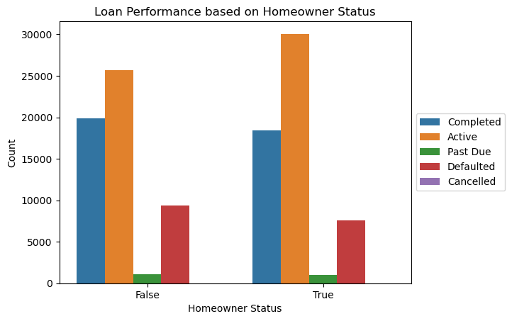

## Does the income range have an impact on the borrower APR, borrower rate, or debt-to-income ratio?

Borrower's income range appeared to have an impact on the borrower APR, borrower rate, and debt-to-income ratio, with higher income resulting in lower borrowing costs and improved loan repayment prospects.

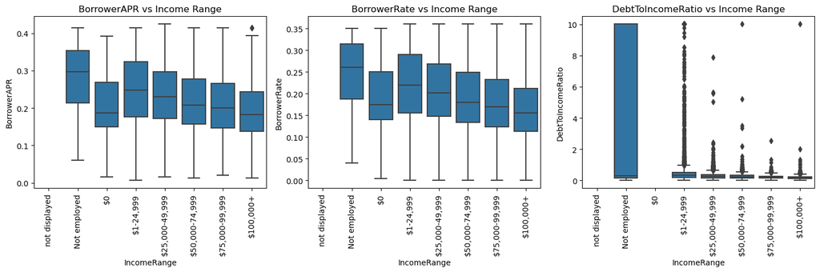

## How does the Prosper risk level impact the loan original amount or monthly loan payment?

Prosper risk level appeared to impact the loan original amount and monthly loan payment, with higher risk levels resulting in smaller loan amounts and lower monthly payments.

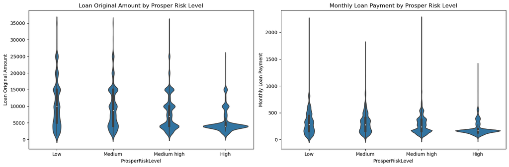

## What is the trend in the average loan original amount over time?

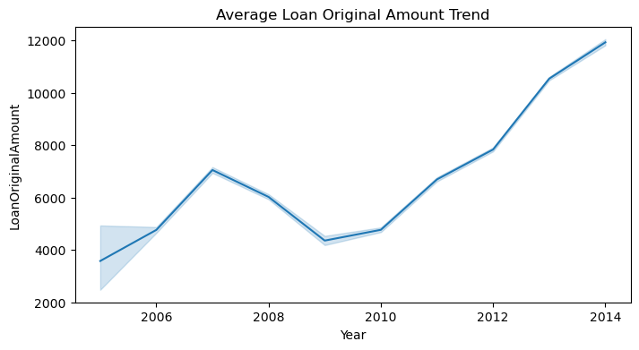